# BellBeat_Analysis

Vinay Tekkur

01/08/2021

Following Questions to get insights from data 1) Is Tracked Distance from user and sensor(tracker/device) is relative? 2) How Daily activities effect the number of calories? 3) How Daily activities effect to user weight? 4) How Daily activities effect to user BMI?

# Installing and Loading packages

```r
#install.packages("tidyverse")
library(tidyverse)
```

# Load the DailyActivities Dataset

```r
dailyActivity_merged <- read_csv("dataset/dailyActivity_merged.csv")
```

## View the dataset

```r
View(dailyActivity_merged)
head(dailyActivity_merged)
```

```
## # A tibble: 6 x 15
##        Id ActivityDate TotalSteps TotalDistance TrackerDistance LoggedActivitie~
##     <dbl> <chr>             <dbl>         <dbl>           <dbl>            <dbl>
## 1  1.50e9 4/12/2016         13162          8.5             8.5                 0
## 2  1.50e9 4/13/2016         10735          6.97            6.97                0
## 3  1.50e9 4/14/2016         10460          6.74            6.74                0
## 4  1.50e9 4/15/2016          9762          6.28            6.28                0
## 5  1.50e9 4/16/2016         12669          8.16            8.16                0
## 6  1.50e9 4/17/2016          9705          6.48            6.48                0
## # ... with 9 more variables: VeryActiveDistance <dbl>,
## #   ModeratelyActiveDistance <dbl>, LightActiveDistance <dbl>,
## #   SedentaryActiveDistance <dbl>, VeryActiveMinutes <dbl>,
## #   FairlyActiveMinutes <dbl>, LightlyActiveMinutes <dbl>,
## #   SedentaryMinutes <dbl>, Calories <dbl>
```

## Get column names of dataset

```r
colnames(dailyActivity_merged)
```

```
##  [1] "Id"                       "ActivityDate"
##  [3] "TotalSteps"               "TotalDistance"
##  [5] "TrackerDistance"          "LoggedActivitiesDistance"
##  [7] "VeryActiveDistance"       "ModeratelyActiveDistance"
##  [9] "LightActiveDistance"      "SedentaryActiveDistance"
## [11] "VeryActiveMinutes"        "FairlyActiveMinutes"
## [13] "LightlyActiveMinutes"     "SedentaryMinutes"
## [15] "Calories"
```

# Relationship between TotalDistance and Tracker Distance

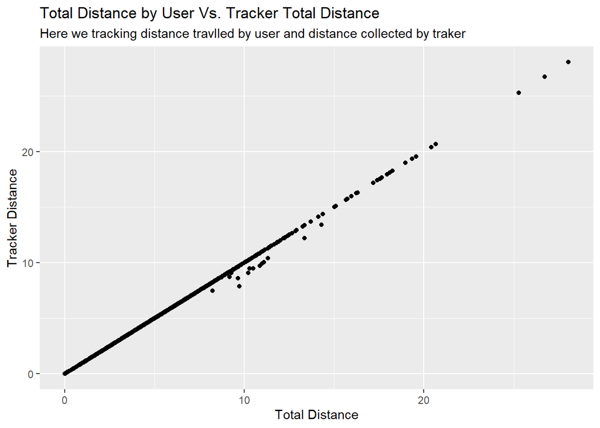

```r
ggplot(data=dailyActivity_merged) +
  geom_point(mapping = aes(x = TotalDistance, y = TrackerDistance)) +
  labs(title = "Total Distance by User Vs. Tracker Total Distance", subtitle = "Here we tracking distance travlled by user and distance collected by traker",
       x = "Total Distance", y = "Tracker Distance")
```

Conclusion: From Visualization it is clear that Distance from user and distance monitored by device or tracker are same except some noise

# Relationships between Total distance Vs Calories

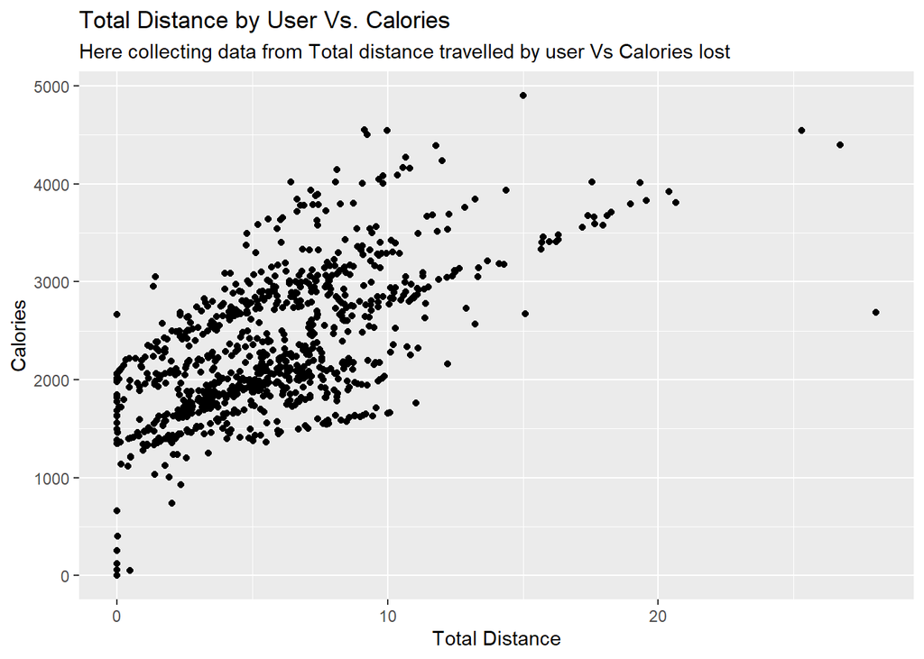

```r
ggplot(data=dailyActivity_merged) +
  geom_point(mapping = aes(x = TotalDistance, y = Calories)) +
  labs(title = "Total Distance by User Vs. Calories", subtitle = "Here collecting data from Total distance travelled by user Vs Calories lost",
       x = "Total Distance")
```

Conclusion: If Activity increases Calories loss also increases

# Load the weightLogInfo_merged Dataset

```r
weightLogInfo_merged <- read_csv("dataset/weightLogInfo_merged.csv")
```

## View the dataset

```r
View(weightLogInfo_merged)
head(weightLogInfo_merged)
```

```
## # A tibble: 6 x 8
##         Id Date       WeightKg WeightPounds   Fat   BMI IsManualReport     LogId
##      <dbl> <chr>         <dbl>        <dbl> <dbl> <dbl> <lgl>              <dbl>
## 1   1.50e9 5/2/2016 ~     52.6         116.    22  22.6 TRUE             1.46e12
## 2   1.50e9 5/3/2016 ~     52.6         116.    NA  22.6 TRUE             1.46e12
## 3   1.93e9 4/13/2016~    134.          294.    NA  47.5 FALSE            1.46e12
## 4   2.87e9 4/21/2016~     56.7         125.    NA  21.5 TRUE             1.46e12
## 5   2.87e9 5/12/2016~     57.3         126.    NA  21.7 TRUE             1.46e12
## 6   4.32e9 4/17/2016~     72.4         160.    25  27.5 TRUE             1.46e12
```

## Get column names of dataset

```r
colnames(weightLogInfo_merged)
```

```
## [1] "Id"             "Date"           "WeightKg"       "WeightPounds"
## [5] "Fat"            "BMI"            "IsManualReport" "LogId"
```

# Get observations from both dataset

```r
nrow(dailyActivity_merged)
```

```
## [1] 940
```

```r
nrow(weightLogInfo_merged)
```

```
## [1] 67
```

# Get Summary of DailyActivities dataset

Summary is calculated on Total Steps and Total Distance of user

```r
dailyActivity_merged %>%
  select(TotalSteps, TotalDistance) %>%
  summary()
```

```
##    TotalSteps    TotalDistance
##  Min.   :    0   Min.   : 0.000
##  1st Qu.: 3790   1st Qu.: 2.620
##  Median : 7406   Median : 5.245
##  Mean   : 7638   Mean   : 5.490
##  3rd Qu.:10727   3rd Qu.: 7.713
##  Max.   :36019   Max.   :28.030
```